# Lab 3 - Parte 1: Entendendo os Dados

André Victor de Andrade Lopes

15 de fevereiro de 2017

A análise atual tem como intuito a **compreensão** dos dados para a predição, bem como a elaboração de atributos para ajudar na classificação dos dados.

# Evasões por ano

O primeiro passo a ser feito é obter os dados e filtrar o que é importante para cada parte da análise. Inicialmente queremos saber **o ano no qual houve mais evasões**.

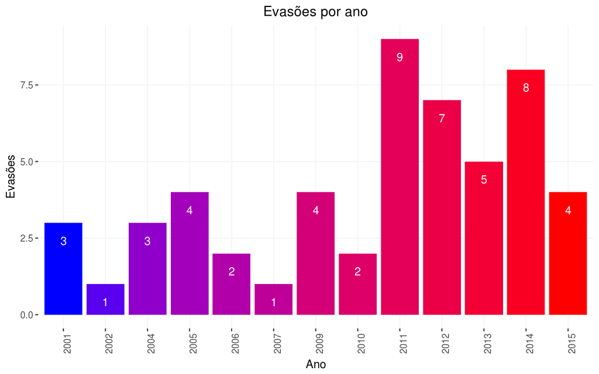

```r
#na.strings=c("")
training.data.raw <- read.csv('treino_classificacao.csv',header=T)

# Get only the necessary columns: Identification, Year and Evasion
training.by.year <- training.data.raw[c(1,4,7)]

#Remove duplicated info from the same student
training.by.year <- aggregate(MAT_TUR_ANO ~ MAT_ALU_MATRICULA + EVADIU, training.by.year,  FUN= mean)

#Get only the data of students that evade
evasions.by.year <- subset(training.by.year, EVADIU)

#Plot the evasion by year
evasions.by.year.plot <- ggplot(evasions.by.year, aes(factor(MAT_TUR_ANO), fill=MAT_TUR_ANO))
evasions.by.year.plot +
  geom_bar() +
  theme(axis.text.x = element_text(angle = 90, hjust = 1)) +
  labs(x = "Ano", y = "Evasões") +
  ggtitle("Evasões por ano") +
  geom_text(stat='count',aes(label=..count.., y = ..count.. -1 ),vjust=-1,color="white") +
  theme(legend.position="none", panel.background = element_rect(fill = "white"), panel.grid.major = element_line(colour = "gray96"), plot.title = element_text(hjust = 0.5)) +
  scale_fill_gradient(low="blue", high="red")
```

Pelo barplot acima, podemos perceber que a quantidade de evasões foi maior no ano de **2011**, com 9 evasões, e em seguida o ano de 2014, com 8 evasões.

# Balanceamento dos dados

Um dos aspectos importantes a ser analisado sobre os dados é se os dados são **balanceados** ou não. Ou seja, se temos ou não uma quantidade balanceada de dados sobre alunos que evadiram e sobre alunos que não evadiram.

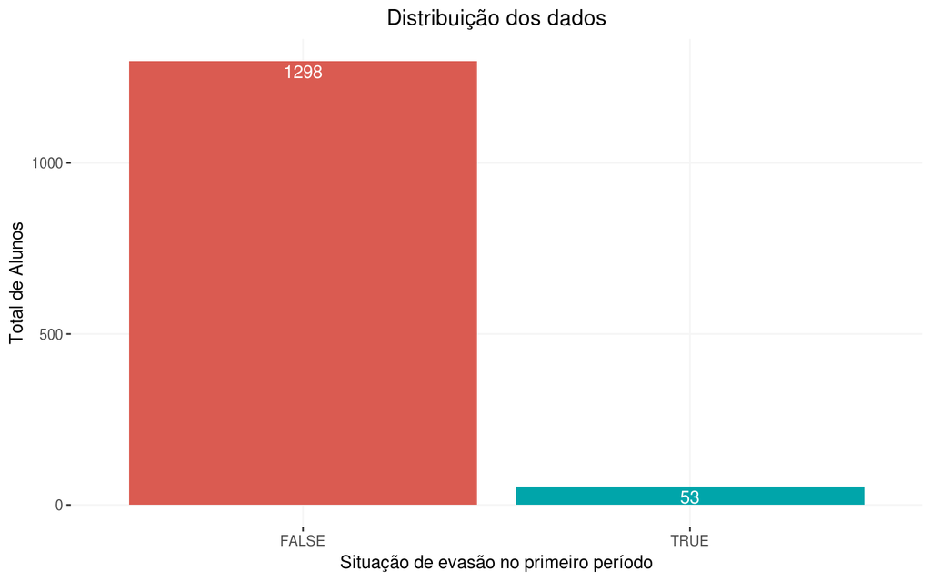

```r
#Plot the amount of students that evaded and the amount of students that didn't evade.
evasion.box.plot <- ggplot(training.by.year , aes(x=EVADIU, fill = EVADIU)) +
  geom_bar(aes(y = (..count..)/sum(..count..), fill = EVADIU), width = 1) +
  labs(x = "Situação de evasão no primeiro período", y = "Total de Alunos") +
  ggtitle("Distribuição dos dados") +
  theme(legend.position="none", panel.background = element_rect(fill = "white"), panel.grid.major = element_line(colour = "gray96"), plot.title = element_text(hjust = 0.5))

evasion.box.plot + geom_bar()  + scale_fill_hue(l=55, c=100) +
  geom_text(stat='count',aes(label=..count.., y = ..count.. -30 ),color="white")
```

Pelo gráfico acima podemos perceber que os dados estão **desbalanceados**. E a desproporção entre as duas classes é muito grande. Temos cerca de *24* estudantes que não evadiram para 1 estudante que evadiu.A quantidade total de dados sobre estudantes que não evadiram é de 1298, enquanto a quantidade de dados sobre estudantes que evadiram é de apenas 53. Com dados desbalanceados fica mais difícil para o algortimo realizar predições corretas, pois não há informação suficiente sobre a classe que está em menor quantidade, no nosso caso, os alunos que evadiram.

# Criando uma nova variável

Inicialmente, iremos transformar as diciplinas em colunas e juntar com os dados que já temos sobre os alunos (o ano, e se ele evadiu ou não). Em seguidas, criamos dois novos atributos. “CadeirasPerdidas” que representa a quantidade de disciplinas que o aluno tem nota inferior a 5, e “Perdeu3”, um atributo booleano que informa se o estudante perdeu mais de 3 cadeiras.

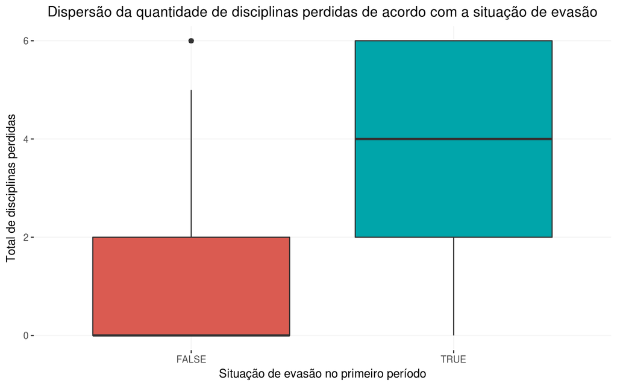

```r
data.by.params <- spread(training.data.raw, key = disciplina, value = MAT_MEDIA_FINAL)
data.by.params[is.na(data.by.params)] <- 0
data.by.params <- data.by.params[c(1,6,7,8,9,10,11)]
data.by.params <- data.by.params %>%
  group_by(MAT_ALU_MATRICULA) %>%
  summarise_each(funs(sum))
data.by.params <- merge(data.by.params, training.by.year, by = "MAT_ALU_MATRICULA")

data.by.params["Perdeu3"] <- FALSE
data.by.params["CadeirasPerdidas"] <- 0

for (j in 1:nrow(data.by.params)){
  x <- data.by.params[j,]
  tt <- 0
  for(i in 2:7) {
    col <- x[i]
     if (col < 5){
       tt<- tt+ 1
       }
  }
    data.by.params[j,11]<- tt
  if(tt>3){
    data.by.params[j,10] <- TRUE
  }

}
data.by.params.perdeu <- subset(data.by.params, EVADIU)
data.perdeu3 <- subset(data.by.params, Perdeu3)
perdeu3.evadiu <- subset(data.perdeu3, EVADIU)
perdeu3.naoevadiu <- subset(data.perdeu3, !EVADIU)

cadeirasperdidas.boxplot <- ggplot(data.by.params, aes(x = EVADIU, y = CadeirasPerdidas, fill = EVADIU)) +
        geom_boxplot()+
        labs(x = "Situação de evasão no primeiro período", y = "Total de disciplinas perdidas") +
        ggtitle("Dispersão da quantidade de disciplinas perdidas de acordo com a situação de evasão") +
  theme(legend.position="none", panel.background = element_rect(fill = "white"), panel.grid.major = element_line(colour = "gray96"), plot.title = element_text(hjust = 0.5))  + scale_fill_hue(l=55, c=100)

cadeirasperdidas.boxplot
```

O gráfico acima mostra o boxplot da variável “CadeirasPeridas” para cada classe (Alunos que evadiram e alunos que não evadiram). Podemos visualizar que a distribuição é bem diferente para cada uma dessas classes.  
Já no grafico abaixo podemos ver que a variável “Perdeu3” é recorrente em grande parte dos alunos que evadiram.

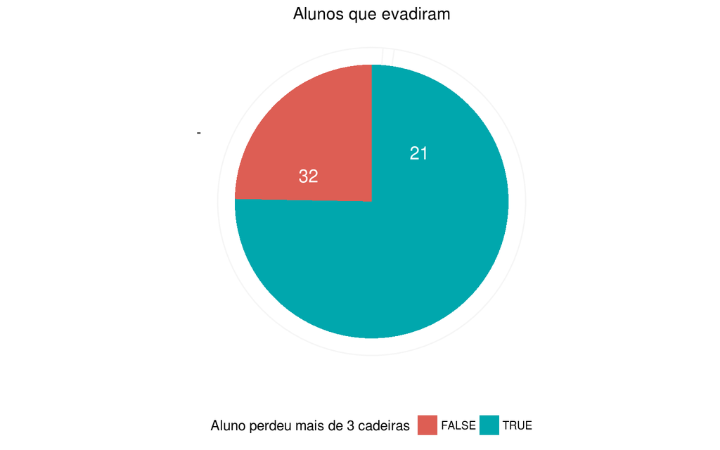

```r
bp<- ggplot(data.by.params.perdeu, aes(x="", factor(Perdeu3), fill=Perdeu3))+
geom_bar(width = 1, stat = "identity") + coord_polar(theta="y", start= 0)  +
  theme(axis.text.x=element_blank(),legend.position="bottom", panel.background = element_rect(fill = "white"), panel.grid.major = element_line(colour = "gray96"), plot.title = element_text(hjust = 0.5))  +
  labs(x="", y="") +
  scale_fill_discrete(l=56, c=100, name = "Aluno perdeu mais de 3 cadeiras") +
  geom_text(stat='count', color="white", aes(label=..count.., y =  ((..count../2) + c(0,cumsum(..count..)[length(..count..)])) ), size = 5) +
        ggtitle("Alunos que evadiram")
bp
```

*Ps: A posição dos numeros estão invertidas*

Outro detalhe é proporção da variavel “Perdeu3”. Nos alunos que evadiram, a variável é verdadeira *(TRUE)* em mais de 60% dos casos. Já nos alunos que não evadiram, a variável é negativa em mais de 80% dos casos *(Ou seja, verdadeira em menos de 20% dos casos)*.